# Geographic distribution

2018-02-06

This example produces on a world map the viability (population growth rate $\lambda$ > 1, $\lambda$ = 1, $\lambda$ < 1) of a subset of studied populations given some selection criteria, and color-codes the location of each population according to the value of $\lambda$.

First, subset mean matrices for all Carnivora in the wild in the northern hemisphere, with no issues for survival >1, for which matrices have been split into **A** = **U** + **F** + **C**, and for which reproduction was explicitly modeled.

Load the data:

```r
load("COMADRE_v.2.0.1.RData")
```

```r
x<-Rcompadre::subsetDB(comadre, MatrixComposite == "Mean" &
                         Order == "Carnivora" &
                         MatrixCaptivity == "W" &
                         Lat > 0 &
                         SurvivalIssue < 1 &
                         MatrixSplit == "Divided" &
                         MatrixFec == "Yes")
```

The object `x` is now a version of the `comadre` database object that contains only the matrices that match the search criteria. To calculate population growth rate for the subset matrices, we can first create an empty `data.frame` to accommodate the output:

```r
output <- data.frame(lambdas = rep(NA, length(x$mat)))
```

Create an empty variable to accommodate output from lambda calculations:

```r
x$metadata$lambdas <- NA
```

Then, create a `for` loop to examine each matrix in turn. Here it may be advisable to use the function `tryCatch` as a wrapper to cope with the situation if/when the function in the loop fails:

```r
for (i in 1:length(x$mat)){
  tryCatch({
    x$metadata$lambdas[i] <- Re(eigen(x$mat[[i]]$matA)$value)[1]
  }, error = function(e){})
}
```

```r
rampfunc <- colorRampPalette(c("green", "red"))
colVect <- rampfunc(100)
colVect <- paste(colVect,"90", sep="")
s1 <- seq(min(x$metadata$lambdas, na.rm=TRUE),max(x$metadata$lambdas, na.rm=TRUE),
          length.out = 100)
```

First, load the `maps` package (and install it if necessary). Then plot the world map and overlay the points from our data, color coded by value of $\lambda$. In this case, the points are jittered slightly to improve visibility of nearby populations.

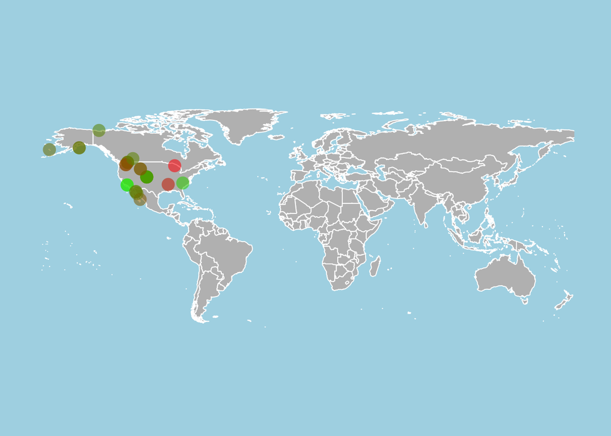

```r
library(maps)
map("world", col = "gray", fill = TRUE, bg = "light blue",
    xlim = c(-175, 176), ylim = c(-60, 85), border = "white")

points(jitter(x$metadata$Lon, 0.6), jitter(x$metadata$Lat, 0.6),
       col = colVect[findInterval(x$metadata$lambdas, s1)],cex = 2, pch = 16)
```